# Social and economic networks

Handout 4.2

Juan José Martín y Christian Strasser

## Ejercicio 2

**The file WikiVote.txt is a data table containing the votations on promotion to administratorship of Wikipedia (till January 2008). Each arc $(x, y)$ in it means that user $x$ voted on $y$ becoming Wikipedia administrator. More details at** http://snap.stanford.edu/data/wiki-Vote.html

**Download it on your computer and upload it to R as a dataframe. Define a directed graph $DW$ with this list of arcs, and the underlying unweighted undirected graph $UW$.**

```r
df = read.csv("datasets/WikiVote.txt", sep="\t")
dw = graph_from_data_frame(df, directed = TRUE)
uw = graph_from_data_frame(df, directed = FALSE)
```

**(a) Does $DW$ contain self-loops? How many? What do self-loops mean, in the context of this graph? If any, remove them (as well as from $UW$).**

```r
sum(which_loop(dw))
```

```
## [1] 0
```

$DW$ no contiene ningún self-loop. No obstante, en el contesto de este grafo, un self-loop sería una arista que tiene como nodo de salia y como nodo de entrada al mismo.

```r
is_simple(uw)
```

```
## [1] FALSE
```

Vemos que $uw$ no es simple, por lo que contiene aristas múltiple o aristas loop, que eliminamos a continuación:

```r
uw = simplify(uw, remove.multiple = TRUE, remove.loops = TRUE, edge.attr.comb = igraph_opt("edge.attr.comb"))
is_simple(uw)
```

```
## [1] TRUE
```

Y ya podemos observar como es simple.

**(b) What are the order and size of $DW$? What is the size of $UW$? What does the difference in sizes correspond to?**

Order y tamaño de $dw$:

```r
gorder(dw)
```

```
## [1] 7115
```

```r
gsize(dw)
```

```
## [1] 103688
```

Tamaño de $uw$:

```r
gsize(uw)
```

```
## [1] 100761
```

Esta diferencia se corresponde a la cantidad de aristas eliminadas de $uw$ que eran multiple o loop.

**(c) Does $DW$ have a giant weakly connected component? And a giant strongly connected component?**

```r
gorder(induced_subgraph(dw, v=groups(components(dw, mode = "weak"))[[1]]))
```

```
## [1] 7066
```

Sí tiene un component conexo gigante débilmente conectado de 7066 nodos.

```r
gorder(induced_subgraph(dw, v=groups(components(dw, mode = "strong"))[[1]]))
```

```
## [1] 1
```

No tiene un component conexo gigante fuertemente conectado ya que el orden es 1.

**(d) Plot its out-degree distribution on a log-log scale (omitting the nodes with out-degree 0).**

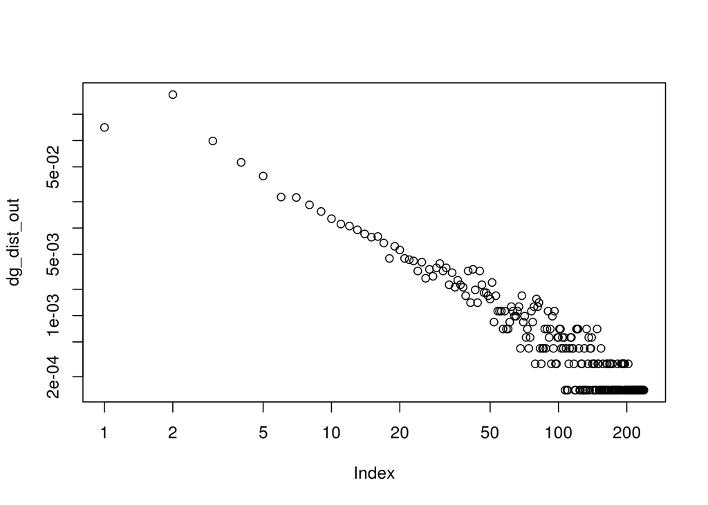

```r
dg_dist_out = degree.distribution(dw, mode="out")
dg_dist_out = dg_dist_out[dg_dist_out != 0]

plot(dg_dist_out, log='xy')
```

**(e) Do the same with its in-degree distribution.**

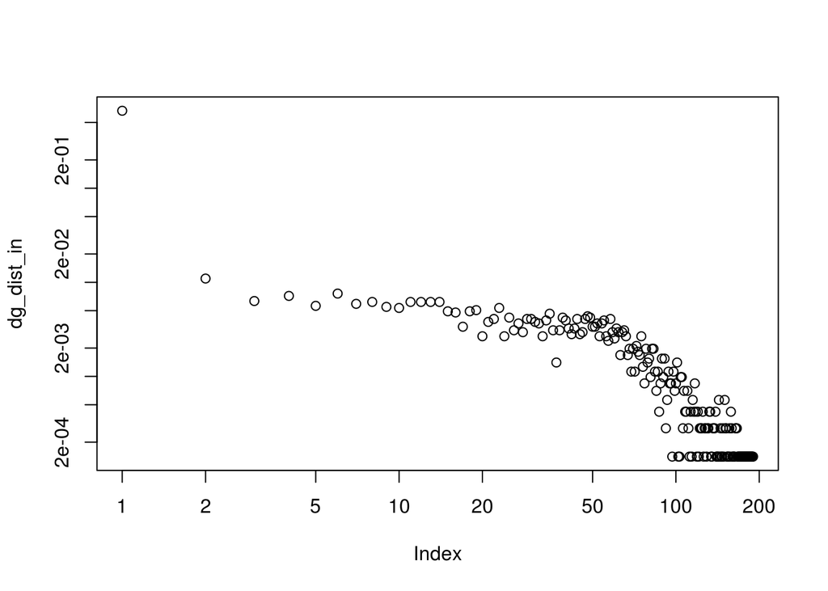

```r
dg_dist_in = degree.distribution(dw, mode="in")
dg_dist_in = dg_dist_in[dg_dist_in != 0]

plot(dg_dist_in, log='xy')
```

**(f) For both the in-degrees and the out-degrees, compute their range, mode, mean, median, and standard deviation. What do they tell you?**

Rango OUT:

```r
range(dg_dist_out)
```

```
## [1] 0.0001405481 0.3347856641
```

Moda OUT:

```r
names(sort(table(degree(dw, mode = "out")), decreasing = TRUE))[1]
```

```
## [1] "1"
```

Media OUT:

```r
mean(dg_dist_out)
```

```
## [1] 0.004201681
```

Mediana OUT:

```r
median(dg_dist_out)
```

```
## [1] 0.0003513703
```

Desviación estándar OUT:

```r
sd(dg_dist_out)
```

```
## [1] 0.02474127
```

Rango IN:

```r
range(dg_dist_in)
```

```
## [1] 0.0001405481 0.6653548840
```

Moda IN:

```r
names(sort(table(degree(dw, mode = "in")), decreasing = TRUE))[1]
```

```
## [1] "0"
```

Media IN:

```r
mean(dg_dist_in)
```

```
## [1] 0.005263158
```

Mediana IN:

```r
median(dg_dist_in)
```

```
## [1] 0.0008432888
```

Desviación estándar IN:

```r
sd(dg_dist_in)
```

```
## [1] 0.0481821
```

**(g) What kind (or kinds) of transitivity do you consider worth studying in this network? Choose at least one, compute it, and comment the results.**

Consideramos oportuno estudiar la transitividad de doble-entrada para medir cuántas veces, por ejemplo, si $X$ e $Y$ muestran estar conectados a $Z$, implica que también deben estar conectados entre sí.

Función para transitividad de doble-entrada:

```r
Local_Double_In_Trans = function(G, x){
  NN = induced_subgraph(G, v = as.vector(neighbors(G, v = x, mode = "in")))
  (sum(which_mutual(NN)) / 2) / choose(gorder(NN), 2)
}
```

```r
Local_Double_In_Trans(dw, 15)
```

```
## [1] 0.003477993
```

Como podemos ver, se trata de un valor muy bajo, por lo que podemos considerar que tendremos más nodos con grado de entrada muy grandes y cuyos nodos que entran en ellos no estarán conectados entre sí.